# IC11-2 — Case 31: Summary of Data Analysis

R1, R2, R5, and R6

Han Mai

## Data and methods

- Employees Federal Credit Union member opinion survey. R reads the cleaned Module 10 SPSS export directly (128 records).
- Percentages use each item’s valid responses. “No opinion” and “No answer” follow the existing missing-value decisions.
- The analysis-table key determines test type. The questionnaire and saved SPSS labels determine category meaning.
- Two-sided one-sample t-tests use the labeled midpoint for interval-treated ratings. Goodness-of-fit tests compare substantive response shares with equal shares. The key gives the test type, and equal shares are the reference assumption used here.

## R1 · Reasons for joining

**Why do people join the Credit Union?**

Q2 allows multiple reasons per member, including convenience, savings rates, personal service, access to borrowing, advertising and Other. The extract lacks Q2, so the distribution of joining reasons is unavailable.

### Savings-rate perception (q7r)

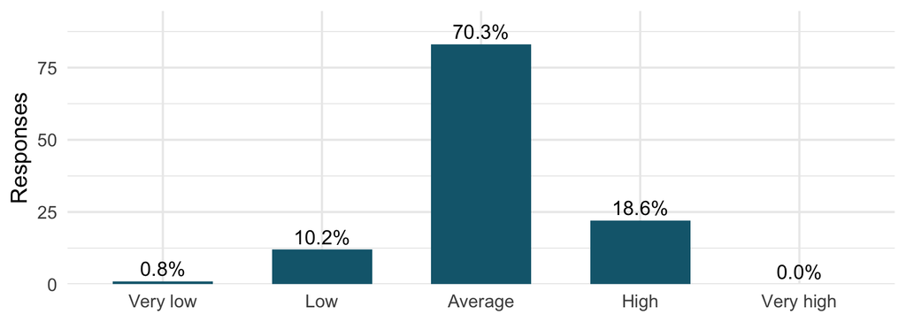

Figure 1: Savings-rate ratings. Bar labels show valid-response percentages.

70.3% of valid respondents rated savings rates **Average** (Figure 1).

## R1 · One-sample t-test

Table 1: Savings-rate rating versus Average.

| Item | n | Mean | SD | Reference | t | df | p |
| --- | --- | --- | --- | --- | --- | --- | --- |
| Savings rates (q7r) | 118 | 3.07 | 0.57 | 3 = Average | 1.30 | 117 | 0.196 |

The data provided insufficient evidence that the mean differed from **Average** (Table 1). The scale runs from Very low to Very high. The item captures members’ assessment of savings rates.

## R2 · Reasons for borrowing elsewhere

**Why do members use other financial institutions when they need to borrow funds?**

- Q28 screens for borrowing elsewhere in the past year. A No response skips Q29. Q29 lists reasons such as better rates, an established credit line and preference for a local institution. Its wording leaves the number of permitted choices unspecified.
- Both fields are absent. The key supplies two contextual measures, **q8r** for perceived borrowing-rate level and **q30** for agreement that EFCU rates are lower than elsewhere.

## R2 · Rate perceptions

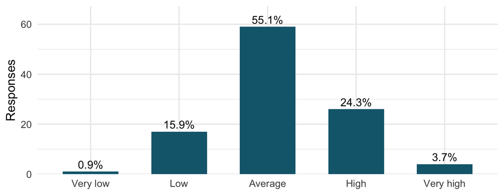

Figure 2: Perceived borrowing-rate level (q8r). Bar labels show valid-response percentages.

55.1% rated borrowing rates **Average** (Figure 2). For q30, 29.7% agreed or strongly agreed that EFCU rates were lower than elsewhere.

## R2 · One-sample t-tests

Table 2: Loan-rate perceptions versus their scale references.

| Item | n | Mean | SD | Reference | t | df | p |
| --- | --- | --- | --- | --- | --- | --- | --- |
| Borrowing rates (q8r) | 107 | 3.14 | 0.76 | 3 = Average | 1.91 | 106 | 0.058 |
| Loan rates lower than elsewhere (q30) | 128 | 3.06 | 0.87 | 3 = Uncertain | 0.82 | 127 | 0.416 |

For q8r, evidence was insufficient to establish a difference from “Average.” For q30, evidence was insufficient to establish a difference from “Uncertain.” See Table 2.

## R5 · Service awareness and use

**How well are the members aware of the services offered by the credit union?**

- Highest awareness: Line of Credit Loans (100.0%).
- Lowest awareness: Regular Share Account (35.2%).
- Signature loans had the largest gap. Awareness was 96.1%, and reported use was 14.8% (81.2 percentage points).
- Each service has one response per member. Total awareness includes both aware categories.

## R5 · Awareness and use (1 of 2)

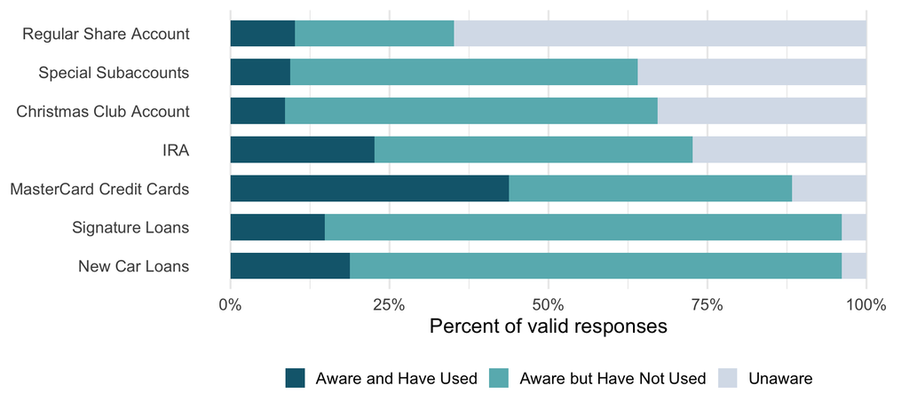

Figure 3: Service awareness and use in questionnaire order.

## R5 · Service frequencies (1 of 2)

Table 3: Counts and valid percentages by service.

| Service | Valid n | Used | Aware, unused | Unaware | Total aware |
| --- | --- | --- | --- | --- | --- |
| Regular Share Account | 128 | 13 (10.2%) | 32 (25.0%) | 83 (64.8%) | 35.2% |
| Special Subaccounts | 128 | 12 (9.4%) | 70 (54.7%) | 46 (35.9%) | 64.1% |
| Christmas Club Account | 128 | 11 (8.6%) | 75 (58.6%) | 42 (32.8%) | 67.2% |
| IRA | 128 | 29 (22.7%) | 64 (50.0%) | 35 (27.3%) | 72.7% |
| MasterCard Credit Cards | 128 | 56 (43.8%) | 57 (44.5%) | 15 (11.7%) | 88.3% |
| Signature Loans | 128 | 19 (14.8%) | 104 (81.2%) | 5 (3.9%) | 96.1% |
| New Car Loans | 128 | 24 (18.8%) | 99 (77.3%) | 5 (3.9%) | 96.1% |

## R5 · Awareness and use (2 of 2)

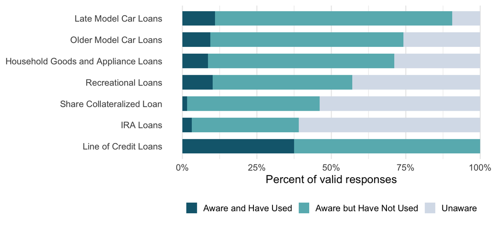

Figure 4: Service awareness and use in questionnaire order.

## R5 · Service frequencies (2 of 2)

Table 4: Counts and valid percentages by service.

| Service | Valid n | Used | Aware, unused | Unaware | Total aware |
| --- | --- | --- | --- | --- | --- |
| Late Model Car Loans | 128 | 14 (10.9%) | 102 (79.7%) | 12 (9.4%) | 90.6% |
| Older Model Car Loans | 128 | 12 (9.4%) | 83 (64.8%) | 33 (25.8%) | 74.2% |
| Household Goods and Appliance Loans | 128 | 11 (8.6%) | 80 (62.5%) | 37 (28.9%) | 71.1% |
| Recreational Loans | 128 | 13 (10.2%) | 60 (46.9%) | 55 (43.0%) | 57.0% |
| Share Collateralized Loan | 128 | 2 (1.6%) | 57 (44.5%) | 69 (53.9%) | 46.1% |
| IRA Loans | 128 | 4 (3.1%) | 46 (35.9%) | 78 (60.9%) | 39.1% |
| Line of Credit Loans | 128 | 48 (37.5%) | 80 (62.5%) | 0 (0.0%) | 100.0% |

## R5 · Goodness of fit

14 of 14 services had response shares that differed from equal thirds at the item-level .05 threshold. The charts show which categories were most common.

| Item | n | χ² | df | p |
| --- | --- | --- | --- | --- |
| Regular Share Account | 128 | 61.42 | 2 | < .001 |
| Special Subaccounts | 128 | 39.81 | 2 | < .001 |
| Christmas Club Account | 128 | 48.02 | 2 | < .001 |
| IRA | 128 | 16.42 | 2 | < .001 |
| MasterCard Credit Cards | 128 | 26.92 | 2 | < .001 |
| Signature Loans | 128 | 134.55 | 2 | < .001 |
| New Car Loans | 128 | 115.80 | 2 | < .001 |

## R5 · Goodness of fit (continued)

| Item | n | χ² | df | p |
| --- | --- | --- | --- | --- |
| Late Model Car Loans | 128 | 123.81 | 2 | < .001 |
| Older Model Car Loans | 128 | 62.36 | 2 | < .001 |
| Household Goods and Appliance Loans | 128 | 56.92 | 2 | < .001 |
| Recreational Loans | 128 | 31.23 | 2 | < .001 |
| Share Collateralized Loan | 128 | 59.83 | 2 | < .001 |
| IRA Loans | 128 | 64.56 | 2 | < .001 |
| Line of Credit Loans | 128 | 76.00 | 2 | < .001 |

## R6 · Operational effectiveness

**What are the members’ attitudes and beliefs about how effectively the credit union is operated?**

- 77.3% said statements came **About Right**.
- 95.3% rated statement accuracy **Good** or **Excellent**. Higher q10r scores indicate better perceived accuracy.
- 97.7% found statements easy to understand, and 69.8% said account information was kept confidential.

## R6 · Statement delivery and accuracy

**q9 · Statement frequency** · valid n = 128

| Response | Count | Valid % |
| --- | --- | --- |
| Too Often | 0 | 0.0% |
| Very Often | 0 | 0.0% |
| About Right | 99 | 77.3% |
| Not Often Enough | 29 | 22.7% |
| Never | 0 | 0.0% |

**q10r · Statement accuracy** · valid n = 128

| Response | Count | Valid % |
| --- | --- | --- |
| Poor | 2 | 1.6% |
| Fair | 4 | 3.1% |
| Good | 54 | 42.2% |
| Excellent | 68 | 53.1% |

## R6 · Clarity and confidentiality

**q11 · Easy to understand** · valid n = 128

| Response | Count | Valid % |
| --- | --- | --- |
| Yes | 125 | 97.7% |
| No | 3 | 2.3% |

**q12 · Kept confidential** · valid n = 106

| Response | Count | Valid % |
| --- | --- | --- |
| Yes | 74 | 69.8% |
| No | 32 | 30.2% |

## R6 · Goodness of fit

Table 5: Response distributions versus equal category shares.

| Item | n | χ² | df | p |
| --- | --- | --- | --- | --- |
| Statement frequency | 128 | 287.70 | 4 | < .001 |
| Statement accuracy | 128 | 108.25 | 3 | < .001 |
| Statements easy to understand | 128 | 116.28 | 1 | < .001 |
| Account information kept confidential | 106 | 16.64 | 1 | < .001 |

The test uses every substantive questionnaire category, including categories with zero responses. The reference is equal shares across five q9 categories, four q10r categories, or two Yes/No categories. See Table 5.

## R6 · Operations and overall management

Table 6: Item-level ratings and two-sided one-sample tests.

| Item | n | Mean | SD | Reference | t | df | p |
| --- | --- | --- | --- | --- | --- | --- | --- |
| Personnel confidentiality (q31) | 128 | 3.95 | 0.68 | 3 = Uncertain | 15.74 | 127 | < .001 |
| Prompt loan processing (q32) | 128 | 3.72 | 0.79 | 3 = Uncertain | 10.25 | 127 | < .001 |
| Services meet member needs (q33) | 128 | 3.59 | 0.68 | 3 = Uncertain | 9.87 | 127 | < .001 |
| Simple loan applications (q34) | 128 | 3.46 | 0.78 | 3 = Uncertain | 6.66 | 127 | < .001 |
| Overall operations (q37r) | 121 | 4.07 | 0.73 | 3 = Average | 16.13 | 120 | < .001 |

Higher q31–q34 ratings indicate stronger agreement. Higher q37r indicates a more favorable overall management and operations rating.

All five means were above their respective scale references (each p < .001).

## R6 · What respondents reported

- 78.1% agreed or strongly agreed that personnel keep personal financial information confidential.
- 60.2% agreed or strongly agreed loan applications are processed promptly.
- 59.4% agreed or strongly agreed that services meet members’ needs.
- 57.8% agreed or strongly agreed that applications are simple to complete.
- 84.3% rated overall operations **Good** or **Excellent**. See Table 6 for comparisons with the scale reference.

## Overall findings

- **R1.** The most common savings-rate rating was **Average**. Joining reasons require Q2.
- **R2.** The rate items describe members’ perceptions of EFCU’s lending rates. The reasons for borrowing elsewhere require Q28 and Q29.
- **R5.** Awareness and use varied by service. The largest gap was for Signature Loans.
- **R6.** Statement accuracy was generally rated favorably, and the overall management and operations rating averaged 4.07 on a five-point scale.

## Limitations

- Both the Module 10 extract and the Module 11 fallback (`Case 31 Data_efcu_4.sav`) lack Q2, Q28 and Q29. The available rate measures describe perceptions. Direct reasons for joining or borrowing elsewhere remain unknown.
- The narrative describes 125 returns and two exclusions. The supplied extract has 128 records, and the case materials do not explain that difference.
- Results describe reported views and use. The q30–q34 items measure separate perceptions. Test p-values are unadjusted and interpreted per item.

## Appendix

- [GitHub repository](https://github.com/hanamai111/case31)
- [GitHub Pages presentation](https://hanamai111.github.io/case31/IC11-2-Case31-Data-Analysis-R1-R2-R5-R6-Han-Mai.html)
- IC10-2-1 data preparation
- IC10-2-2 analysis table
- [Case 31 questionnaire and coding exhibit](https://github.com/jaejungca/case31/blob/main/Case%2031%20-%20Employees%20Federal%20Credit%20Union.PDF)
- [Workshop demonstration](https://www.youtube.com/watch?v=CKjH-nWKbFU&t=4432s)